# Proposed Chionoecetes/Hemat. Study

2021-11-08

## Plan Summary

- Examine genetic differences over space, time, and host species in Alaskan *Chionoecetes* and *Hematodinium*
  - Changes in host, parasite, host/parasite interactions
  - Determine *Hematodinium* population structure
  - Measure *Hematodinium* gene flow
  - Better understand *Hematodinium* transmission dynamics
- Possible exploration of 2020-2021 mortality event
- Funding source: NPRB

## NPRB Summary

- Rolling deadline (began Sept. 28th)
- Timeline:
  - 1-6 months: Proposal peer review
  - Dates TBD: Approved at board meeting
  - 1 year: NRPB suggested project start date
- Co-funding partners: **BSFRF**, Oil Spill Recovery Institute, Pollock Conservation Cooperative Research Center

## NPRB: Research Category

- Goal research category: Fishes and Invertebrates
  - Project cap: $600,000
  - Total goal: $1,000,000
- Relevant general topics:
  - Estimation of life history parameters that impact stock assessments
  - Ecology and physiology of forage species
  - Characterization of cross-species interactions
  - Analyses of survey design and data (depending on methods)
    - qPCR vs. cPCR vs. histology

## Next Steps

- Iron out specifics of methods
- Ensure samples can be extracted and amplified
- Apply for NPRB!

## Sample Description

Samples were shipped from Pam Jensen to the Roberts Lab upon her retirement from NOAA.

Uses Pam’s data tables - which have not yet been cross-referenced with the physical samples - as the data source.

Total samples: 27,387

## Sample Storage

- Majority: hemolymph samples in deep well plates
- Minority: tissue samples in tubes
- All: Preserved in 100% EtOH

## Sample Location

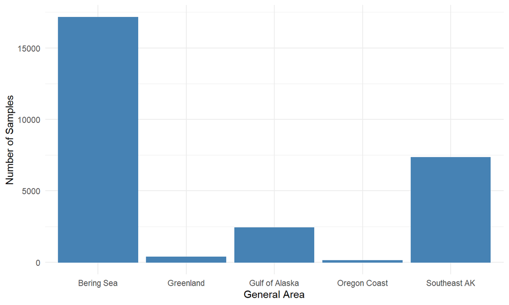

## Background: Sample Taxa

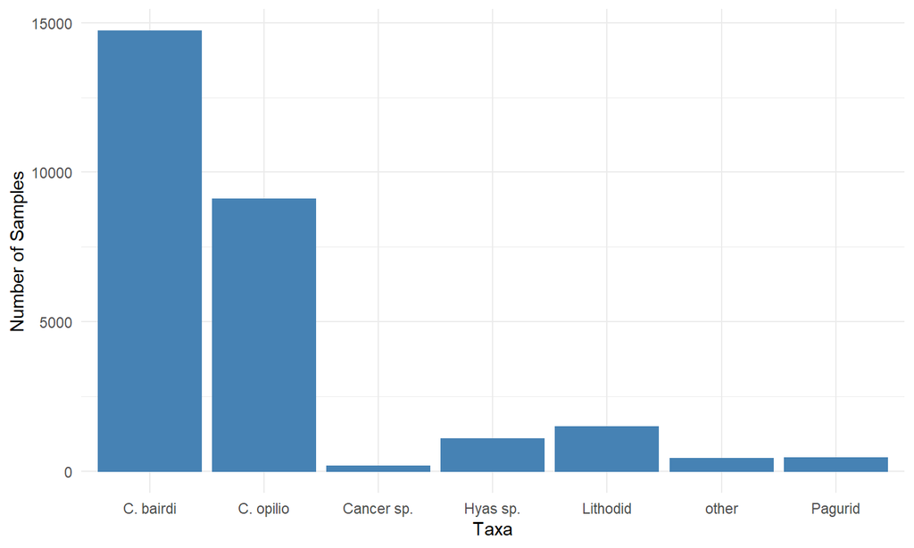

## Background: Year

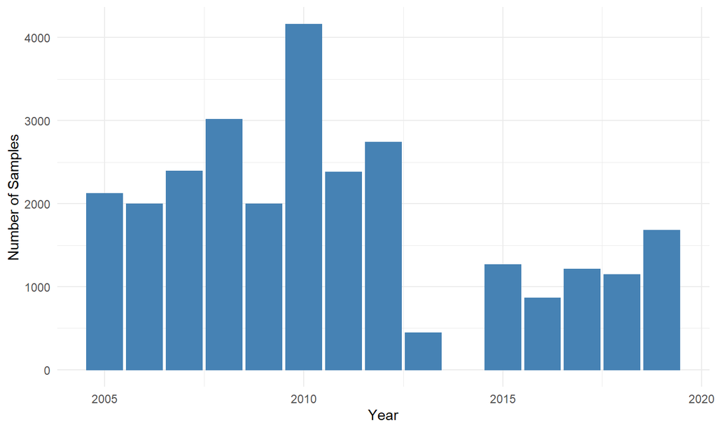